# Model Map Fact Sheet

Oak Ridges Moraine Groundwater Program

09/12/2021

# Introduction

The Oak Ridges Moraine Groundwater Program (ORMGP) has been supporting partner agencies with their numerical modelling studies for many years. Because of the large number of models that have been developed within the ORMGP area, many models exist, from local-scale water budgets to regional-scale, three-dimensional groundwater flow models. The Model Mapping Tool (under development) is a new feature on the ORMGP mapping website. This tool allows users to identify all documented numerical models that are associated with a selected watershed or municipal boundary.

# Model Mapping Tool

While the model-mapping tool is under development, it can be accessed on the Partners’ website by opening the Consolidated Mapping feature. From there, click the “I want to…” button, as seen below:

[figure not shown]

*Figure 1: Getting Started with the Model Mapping Tool*

The ORMGP website can display the model boundaries for all documented modelling studies in the ORM area. To support partner agencies, website users now have the ability to select a municipal or watershed boundary and see all models that are affiliated with that boundary.

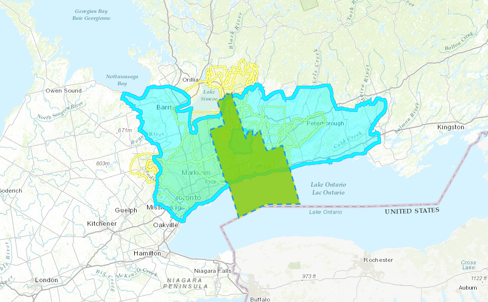

*Figure 2: Durham Region and associated models*

# Level 1 (WT1)

### Incorporation of Streams

Given the interconnectedness of the groundwater and surface water systems across the ORMGP area, as evidenced by the prevalence of perennial streams, it is postulated that, as groundwater discharges to streams, the streams reflect the elevation of the water table. By distributing “stream nodes” at an approximate 500 m spacing along mapped watercourses, elevations are collected as surrogate water table points allowing for the interpolated water table to be constrained in river valleys.